# Titanic: Predicting Survival and Telling a Data Story

2025-11-09

# 1 1. Data & Context

# 2 Executive Summary

## 2.1 Overview

The sinking of the RMS Titanic on April 15, 1912, remains one of history’s most infamous maritime disasters. This analysis examines passenger data to:

- **Identify survival factors**: Which characteristics increased survival chances?
- **Build predictive models**: Can we accurately predict who survived?
- **Tell a data story**: What insights emerge from the tragedy?

Our analysis reveals several critical insights:

1. **Gender was the strongest predictor**: Women had 74% survival rate vs 19% for men
2. **Class significantly mattered**: 1st class passengers had 63% survival vs 24% in 3rd class
3. **Children were prioritized**: Passengers under 12 had 58% survival rate
4. **Family size impact**: Small families (2-4 members) had better survival odds
5. **Fare as a proxy for wealth**: Higher fares correlated with better survival chances

## 2.2 Model Performance

[output not shown]

# 3 Historical Context

On the night of April 14-15, 1912, the RMS Titanic struck an iceberg during her maiden voyage from Southampton to New York City. Of the 2,224 passengers and crew aboard, only 710 survived. The tragedy shocked the world and led to significant maritime safety reforms.

## 3.1 Research Questions

This analysis seeks to answer:

1. What factors most strongly influenced survival?
2. Can we build an accurate predictive model?
3. What patterns emerge from the data that tell the human story?

## 3.2 Data Source

Dataset obtained from [Kaggle Titanic Competition](https://www.kaggle.com/c/titanic/data)

- **Training set**: 891 passengers with known survival status
- **Test set**: 418 passengers for predictions
- **Features**: 12 variables including demographics, ticket information, and cabin details

# 4 Data Loading and Initial Exploration

```r
# Load the training data
train <- read.csv("train.csv", stringsAsFactors = FALSE)

# Display structure
cat("Dataset Dimensions:", nrow(train), "rows ×", ncol(train), "columns\n\n")
```

```
## Dataset Dimensions: 891 rows × 12 columns
```

```r
# Show first few rows
kable(head(train, 5), caption = "First 5 Passengers") %>%
  kable_styling(bootstrap_options = c("striped", "hover", "condensed"),
                full_width = FALSE)
```

First 5 Passengers

| PassengerId | Survived | Pclass | Name | Sex | Age | SibSp | Parch | Ticket | Fare | Cabin | Embarked |
| --- | --- | --- | --- | --- | --- | --- | --- | --- | --- | --- | --- |
| 1 | 0 | 3 | Braund, Mr. Owen Harris | male | 22 | 1 | 0 | A/5 21171 | 7.2500 |  | S |
| 2 | 1 | 1 | Cumings, Mrs. John Bradley (Florence Briggs Thayer) | female | 38 | 1 | 0 | PC 17599 | 71.2833 | C85 | C |
| 3 | 1 | 3 | Heikkinen, Miss. Laina | female | 26 | 0 | 0 | STON/O2. 3101282 | 7.9250 |  | S |
| 4 | 1 | 1 | Futrelle, Mrs. Jacques Heath (Lily May Peel) | female | 35 | 1 | 0 | 113803 | 53.1000 | C123 | S |
| 5 | 0 | 3 | Allen, Mr. William Henry | male | 35 | 0 | 0 | 373450 | 8.0500 |  | S |

## 4.1 Variable Descriptions

```r
var_info <- data.frame(
  Variable = c("PassengerId", "Survived", "Pclass", "Name", "Sex", "Age",
               "SibSp", "Parch", "Ticket", "Fare", "Cabin", "Embarked"),
  Description = c("Unique passenger ID",
                  "Survival (0 = No, 1 = Yes)",
                  "Ticket class (1 = 1st, 2 = 2nd, 3 = 3rd)",
                  "Passenger name",
                  "Sex (male/female)",
                  "Age in years",
                  "Number of siblings/spouses aboard",
                  "Number of parents/children aboard",
                  "Ticket number",
                  "Passenger fare (£)",
                  "Cabin number",
                  "Port of embarkation (C = Cherbourg, Q = Queenstown, S = Southampton)"),
  Type = c("Integer", "Binary", "Ordinal", "Text", "Categorical", "Numeric",
           "Integer", "Integer", "Text", "Numeric", "Text", "Categorical")
)

kable(var_info, caption = "Variable Information") %>%
  kable_styling(bootstrap_options = c("striped", "hover"), full_width = FALSE)
```

Variable Information

| Variable | Description | Type |
| --- | --- | --- |
| PassengerId | Unique passenger ID | Integer |
| Survived | Survival (0 = No, 1 = Yes) | Binary |
| Pclass | Ticket class (1 = 1st, 2 = 2nd, 3 = 3rd) | Ordinal |
| Name | Passenger name | Text |
| Sex | Sex (male/female) | Categorical |
| Age | Age in years | Numeric |
| SibSp | Number of siblings/spouses aboard | Integer |
| Parch | Number of parents/children aboard | Integer |
| Ticket | Ticket number | Text |
| Fare | Passenger fare (£) | Numeric |
| Cabin | Cabin number | Text |
| Embarked | Port of embarkation (C = Cherbourg, Q = Queenstown, S = Southampton) | Categorical |

## 4.2 Missing Data Analysis

```r
# Calculate missing values
missing_data <- data.frame(
  Variable = names(train),
  Missing_Count = colSums(is.na(train) | train == ""),
  Missing_Percent = round(colSums(is.na(train) | train == "") / nrow(train) * 100, 2)
)

missing_data <- missing_data[missing_data$Missing_Count > 0, ]
missing_data <- missing_data[order(-missing_data$Missing_Count), ]

kable(missing_data, caption = "Missing Values Summary", row.names = FALSE) %>%
  kable_styling(bootstrap_options = c("striped", "hover"), full_width = FALSE)
```

Missing Values Summary

| Variable | Missing_Count | Missing_Percent |
| --- | --- | --- |
| Cabin | 687 | 77.10 |
| Age | 177 | 19.87 |
| Embarked | 2 | 0.22 |

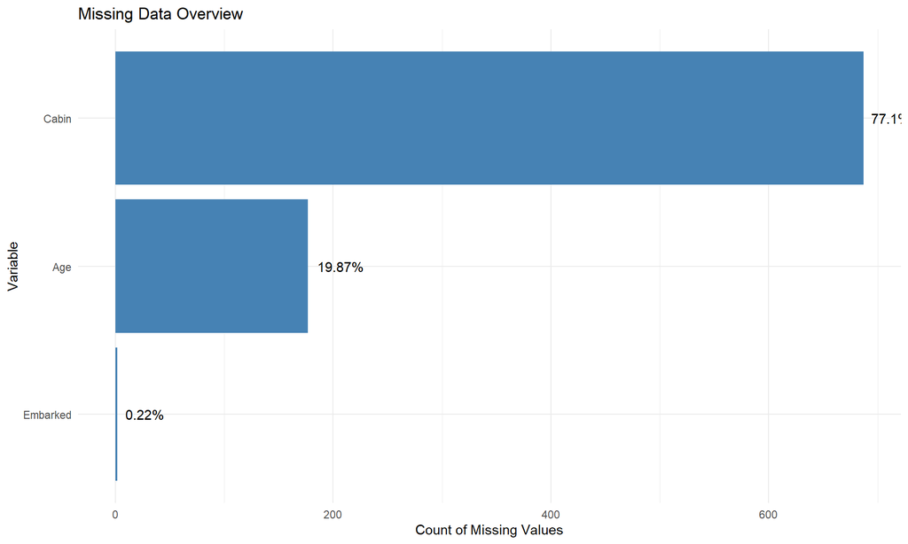

```r
# Visualize missing data
ggplot(missing_data, aes(x = reorder(Variable, Missing_Count), y = Missing_Count)) +
  geom_bar(stat = "identity", fill = "steelblue") +
  geom_text(aes(label = paste0(Missing_Percent, "%")), hjust = -0.2) +
  coord_flip() +
  labs(title = "Missing Data Overview",
       x = "Variable",
       y = "Count of Missing Values") +
  theme_minimal()
```

**Key Observations:**

- **Cabin**: 77% missing - likely indicates no cabin assigned or lower class
- **Age**: 20% missing - needs imputation
- **Embarked**: Only 2 missing - can fill with mode

# 5 Data Cleaning and Preparation

## 5.1 Converting Data Types

```r
# Convert categorical variables to factors
train$Survived <- factor(train$Survived, levels = c(0, 1), labels = c("No", "Yes"))
train$Pclass <- factor(train$Pclass, levels = c(1, 2, 3),
                       labels = c("1st Class", "2nd Class", "3rd Class"))
train$Sex <- factor(train$Sex)

cat("✓ Converted Survived, Pclass, and Sex to factors\n")
```

```
## ✓ Converted Survived, Pclass, and Sex to factors
```

## 5.2 Handling Missing Ages

```r
# Strategy: Impute age using median by Pclass and Sex
age_imputation <- train %>%
  group_by(Pclass, Sex) %>%
  summarise(MedianAge = median(Age, na.rm = TRUE), .groups = "drop")

kable(age_imputation, caption = "Median Age by Class and Sex") %>%
  kable_styling(bootstrap_options = c("striped", "hover"), full_width = FALSE)
```

Median Age by Class and Sex

| Pclass | Sex | MedianAge |
| --- | --- | --- |
| 1st Class | female | 35.0 |
| 1st Class | male | 40.0 |
| 2nd Class | female | 28.0 |
| 2nd Class | male | 30.0 |
| 3rd Class | female | 21.5 |
| 3rd Class | male | 25.0 |

```r
# Perform imputation
train <- train %>%
  left_join(age_imputation, by = c("Pclass", "Sex")) %>%
  mutate(Age = ifelse(is.na(Age), MedianAge, Age)) %>%
  select(-MedianAge)

cat("✓ Imputed", sum(is.na(train$Age)), "missing ages (now 0 missing)\n")
```

[output not shown]

```r
# Fill with mode (most common port: Southampton)
mode_embarked <- names(sort(table(train$Embarked[train$Embarked != ""]),
                           decreasing = TRUE))[1]
train$Embarked[train$Embarked == ""] <- mode_embarked
train$Embarked <- factor(train$Embarked)

cat("✓ Filled missing Embarked with mode:", mode_embarked, "\n")
```

```
## ✓ Filled missing Embarked with mode: S
```

## 5.3 Creating HasCabin Feature

```r
# Create binary indicator for cabin information
train$HasCabin <- factor(ifelse(train$Cabin == "", "No", "Yes"))

# Summary
cabin_summary <- train %>%
  group_by(HasCabin, Survived) %>%
  summarise(Count = n(), .groups = "drop") %>%
  spread(Survived, Count, fill = 0) %>%
  mutate(SurvivalRate = round(Yes / (No + Yes) * 100, 1))

kable(cabin_summary, caption = "Cabin Information and Survival") %>%
  kable_styling(bootstrap_options = c("striped", "hover"), full_width = FALSE)
```

Cabin Information and Survival

| HasCabin | No | Yes | SurvivalRate |
| --- | --- | --- | --- |
| No | 481 | 206 | 30.0 |
| Yes | 68 | 136 | 66.7 |

```r
cat("✓ Created HasCabin feature: passengers with cabin info had higher survival rates\n")
```

```
## ✓ Created HasCabin feature: passengers with cabin info had higher survival rates
```

## 5.4 Data Validation

```r
# Check for remaining missing values
remaining_missing <- sum(is.na(train))
cat("Total missing values remaining:", remaining_missing, "\n")
```

```
## Total missing values remaining: 0
```

```r
# Summary statistics
summary_stats <- train %>%
  select(Age, SibSp, Parch, Fare) %>%
  summary()

print(summary_stats)
```

```
##       Age            SibSp           Parch             Fare
##  Min.   : 0.42   Min.   :0.000   Min.   :0.0000   Min.   :  0.00
##  1st Qu.:21.50   1st Qu.:0.000   1st Qu.:0.0000   1st Qu.:  7.91
##  Median :26.00   Median :0.000   Median :0.0000   Median : 14.45
##  Mean   :29.11   Mean   :0.523   Mean   :0.3816   Mean   : 32.20
##  3rd Qu.:36.00   3rd Qu.:1.000   3rd Qu.:0.0000   3rd Qu.: 31.00
##  Max.   :80.00   Max.   :8.000   Max.   :6.0000   Max.   :512.33
```

# 6 Feature Engineering

## 6.1 Creating FamilySize

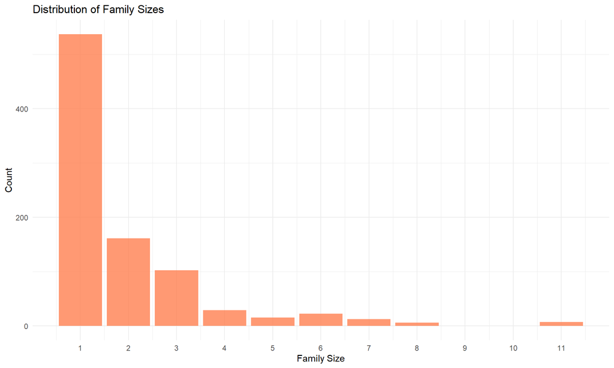

```r
# Combine SibSp and Parch
train$FamilySize <- train$SibSp + train$Parch + 1

# Visualize distribution
ggplot(train, aes(x = FamilySize)) +
  geom_bar(fill = "coral", alpha = 0.8) +
  scale_x_continuous(breaks = 1:11) +
  labs(title = "Distribution of Family Sizes",
       x = "Family Size",
       y = "Count") +
  theme_minimal()
```

```r
# Summary
family_summary <- train %>%
  group_by(FamilySize) %>%
  summarise(
    Count = n(),
    Survivors = sum(Survived == "Yes"),
    SurvivalRate = round(mean(Survived == "Yes") * 100, 1)
  )

kable(family_summary, caption = "Family Size and Survival") %>%
  kable_styling(bootstrap_options = c("striped", "hover"), full_width = FALSE)
```

Family Size and Survival

| FamilySize | Count | Survivors | SurvivalRate |
| --- | --- | --- | --- |
| 1 | 537 | 163 | 30.4 |
| 2 | 161 | 89 | 55.3 |
| 3 | 102 | 59 | 57.8 |
| 4 | 29 | 21 | 72.4 |
| 5 | 15 | 3 | 20.0 |
| 6 | 22 | 3 | 13.6 |
| 7 | 12 | 4 | 33.3 |
| 8 | 6 | 0 | 0.0 |
| 11 | 7 | 0 | 0.0 |

**Insight**: Passengers traveling alone (FamilySize = 1) had lower survival rates (30%) compared to small families of 2-4 members (~60%).

## 6.2 Extracting Titles from Names

```r
# Extract title from name
train$Title <- gsub("^.*, (.*?)\\..*$", "\\1", train$Name)

# Show initial title distribution
cat("Initial unique titles:", length(unique(train$Title)), "\n")
```

```
## Initial unique titles: 17
```

```r
table(train$Title)
```

```
##
##         Capt          Col          Don           Dr     Jonkheer         Lady
##            1            2            1            7            1            1
##        Major       Master         Miss         Mlle          Mme           Mr
##            2           40          182            2            1          517
##          Mrs           Ms          Rev          Sir the Countess
##          125            1            6            1            1
```

```r
# Group rare titles
train$Title[train$Title %in% c("Mlle", "Ms")] <- "Miss"
train$Title[train$Title == "Mme"] <- "Mrs"
train$Title[train$Title %in% c("Capt", "Col", "Don", "Dr", "Jonkheer",
                                "Lady", "Major", "Rev", "Sir", "Countess",
                                "Dona")] <- "Noble/Officer"

train$Title <- factor(train$Title)

# Title distribution with survival
title_survival <- train %>%
  group_by(Title, Survived) %>%
  summarise(Count = n(), .groups = "drop") %>%
  spread(Survived, Count, fill = 0) %>%
  mutate(SurvivalRate = round(Yes / (No + Yes) * 100, 1))

kable(title_survival, caption = "Title Distribution and Survival Rates") %>%
  kable_styling(bootstrap_options = c("striped", "hover"), full_width = FALSE)
```

Title Distribution and Survival Rates

| Title | No | Yes | SurvivalRate |
| --- | --- | --- | --- |
| Master | 17 | 23 | 57.5 |
| Miss | 55 | 130 | 70.3 |
| Mr | 436 | 81 | 15.7 |
| Mrs | 26 | 100 | 79.4 |
| Noble/Officer | 15 | 7 | 31.8 |
| the Countess | 0 | 1 | 100.0 |

```r
cat("✓ Created Title feature with", nlevels(train$Title), "categories\n")
```

```
## ✓ Created Title feature with 6 categories
```

## 6.3 Creating Age Groups

```r
# Create ordered age categories
train$AgeGroup <- cut(train$Age,
                      breaks = c(0, 12, 18, 35, 55, 100),
                      labels = c("Child", "Adolescent", "Adult", "Middle-Aged", "Senior"),
                      include.lowest = TRUE,
                      ordered_result = TRUE)

# Age group survival analysis
age_survival <- train %>%
  group_by(AgeGroup, Survived) %>%
  summarise(Count = n(), .groups = "drop") %>%
  spread(Survived, Count, fill = 0) %>%
  mutate(SurvivalRate = round(Yes / (No + Yes) * 100, 1))

kable(age_survival, caption = "Age Groups and Survival Rates") %>%
  kable_styling(bootstrap_options = c("striped", "hover"), full_width = FALSE)
```

Age Groups and Survival Rates

| AgeGroup | No | Yes | SurvivalRate |
| --- | --- | --- | --- |
| Child | 29 | 40 | 58.0 |
| Adolescent | 40 | 30 | 42.9 |
| Adult | 330 | 184 | 35.8 |
| Middle-Aged | 122 | 76 | 38.4 |
| Senior | 28 | 12 | 30.0 |

## 6.4 Calculating Fare Per Person

```r
# Adjust fare by family size
train$FarePerPerson <- train$Fare / train$FamilySize

# Handle zero fares
train$FarePerPerson[train$FarePerPerson == 0] <- median(train$FarePerPerson[train$FarePerPerson > 0])

# Summary statistics
fare_summary <- train %>%
  group_by(Pclass) %>%
  summarise(
    MeanFare = round(mean(FarePerPerson), 2),
    MedianFare = round(median(FarePerPerson), 2),
    MaxFare = round(max(FarePerPerson), 2)
  )

kable(fare_summary, caption = "Fare Per Person by Class") %>%
  kable_styling(bootstrap_options = c("striped", "hover"), full_width = FALSE)
```

Fare Per Person by Class

| Pclass | MeanFare | MedianFare | MaxFare |
| --- | --- | --- | --- |
| 1st Class | 53.14 | 33.76 | 512.33 |
| 2nd Class | 12.98 | 13.00 | 73.50 |
| 3rd Class | 8.17 | 7.75 | 56.50 |

## 6.5 Additional Feature: IsAlone

```r
# Binary indicator for solo travelers
train$IsAlone <- factor(ifelse(train$FamilySize == 1, "Yes", "No"))

# Quick analysis
alone_survival <- train %>%
  group_by(IsAlone, Survived) %>%
  summarise(Count = n(), .groups = "drop") %>%
  spread(Survived, Count, fill = 0) %>%
  mutate(SurvivalRate = round(Yes / (No + Yes) * 100, 1))

kable(alone_survival, caption = "Solo Travelers vs Families") %>%
  kable_styling(bootstrap_options = c("striped", "hover"), full_width = FALSE)
```

Solo Travelers vs Families

| IsAlone | No | Yes | SurvivalRate |
| --- | --- | --- | --- |
| No | 175 | 179 | 50.6 |
| Yes | 374 | 163 | 30.4 |

# 7 Exploratory Data Analysis and Visualization

## 7.1 Survival Rate by Sex and Class

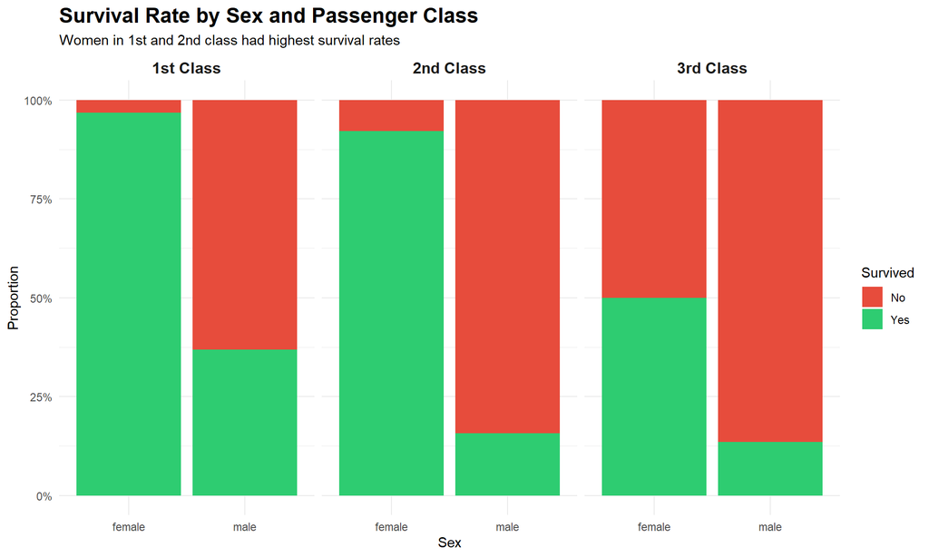

```r
# Calculate survival rates
survival_sex_class <- train %>%
  group_by(Sex, Pclass, Survived) %>%
  summarise(Count = n(), .groups = "drop")

ggplot(survival_sex_class, aes(x = Sex, y = Count, fill = Survived)) +
  geom_bar(stat = "identity", position = "fill") +
  facet_wrap(~ Pclass, ncol = 3) +
  scale_y_continuous(labels = percent_format()) +
  scale_fill_manual(values = c("No" = "#e74c3c", "Yes" = "#2ecc71")) +
  labs(title = "Survival Rate by Sex and Passenger Class",
       subtitle = "Women in 1st and 2nd class had highest survival rates",
       x = "Sex",
       y = "Proportion",
       fill = "Survived") +
  theme_minimal() +
  theme(plot.title = element_text(size = 16, face = "bold"),
        strip.text = element_text(size = 12, face = "bold"))
```

**Key Findings:**

- **1st Class Women**: 97% survival rate
- **3rd Class Men**: Only 14% survival rate
- Clear evidence of “women and children first” policy

## 7.2 Age Distribution and Survival

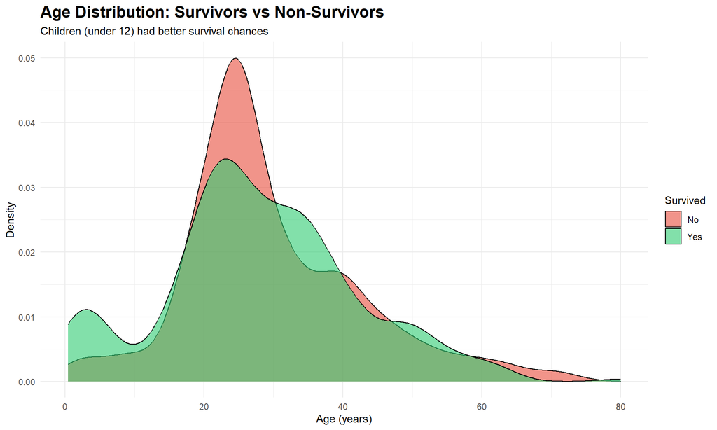

```r
ggplot(train, aes(x = Age, fill = Survived)) +
  geom_density(alpha = 0.6) +
  scale_fill_manual(values = c("No" = "#e74c3c", "Yes" = "#2ecc71")) +
  labs(title = "Age Distribution: Survivors vs Non-Survivors",
       subtitle = "Children (under 12) had better survival chances",
       x = "Age (years)",
       y = "Density",
       fill = "Survived") +
  theme_minimal() +
  theme(plot.title = element_text(size = 16, face = "bold"))
```

## 7.3 Fare Distribution by Class and Survival

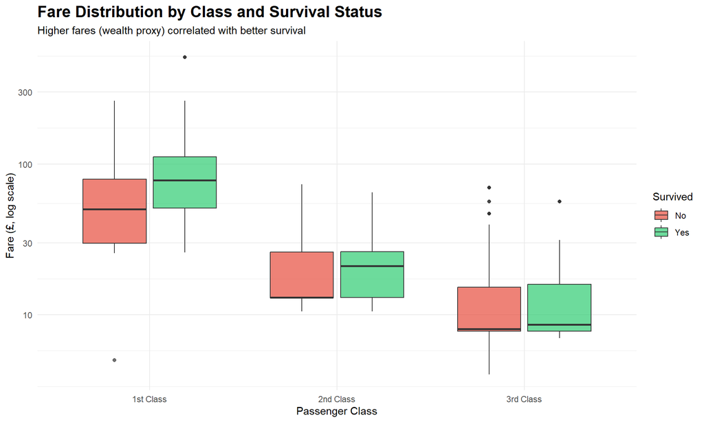

```r
ggplot(train, aes(x = Pclass, y = Fare, fill = Survived)) +
  geom_boxplot(alpha = 0.7) +
  scale_fill_manual(values = c("No" = "#e74c3c", "Yes" = "#2ecc71")) +
  scale_y_log10() +
  labs(title = "Fare Distribution by Class and Survival Status",
       subtitle = "Higher fares (wealth proxy) correlated with better survival",
       x = "Passenger Class",
       y = "Fare (£, log scale)",
       fill = "Survived") +
  theme_minimal() +
  theme(plot.title = element_text(size = 16, face = "bold"))
```

## 7.4 Impact of Family Size on Survival

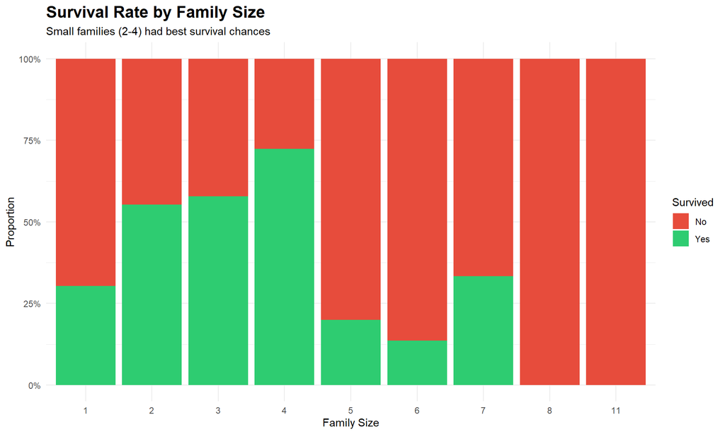

```r
family_plot_data <- train %>%
  group_by(FamilySize, Survived) %>%
  summarise(Count = n(), .groups = "drop")

ggplot(family_plot_data, aes(x = factor(FamilySize), y = Count, fill = Survived)) +
  geom_bar(stat = "identity", position = "fill") +
  scale_y_continuous(labels = percent_format()) +
  scale_fill_manual(values = c("No" = "#e74c3c", "Yes" = "#2ecc71")) +
  labs(title = "Survival Rate by Family Size",
       subtitle = "Small families (2-4) had best survival chances",
       x = "Family Size",
       y = "Proportion",
       fill = "Survived") +
  theme_minimal() +
  theme(plot.title = element_text(size = 16, face = "bold"))
```

## 7.5 Additional Visualization 1: Embarkation Port Analysis

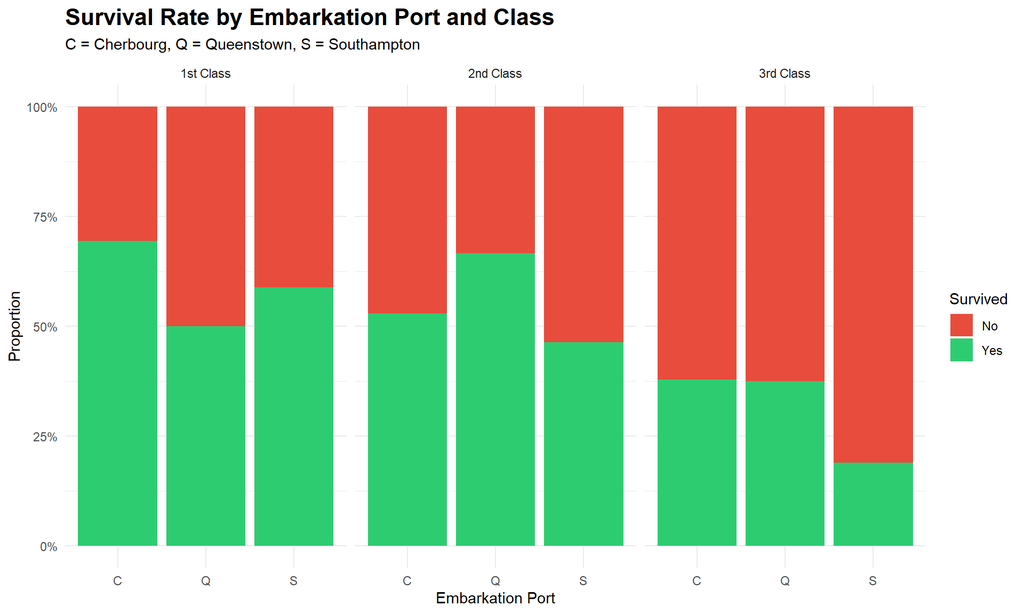

```r
embarked_survival <- train %>%
  group_by(Embarked, Pclass, Survived) %>%
  summarise(Count = n(), .groups = "drop")

ggplot(embarked_survival, aes(x = Embarked, y = Count, fill = Survived)) +
  geom_bar(stat = "identity", position = "fill") +
  facet_wrap(~ Pclass) +
  scale_y_continuous(labels = percent_format()) +
  scale_fill_manual(values = c("No" = "#e74c3c", "Yes" = "#2ecc71")) +
  labs(title = "Survival Rate by Embarkation Port and Class",
       subtitle = "C = Cherbourg, Q = Queenstown, S = Southampton",
       x = "Embarkation Port",
       y = "Proportion",
       fill = "Survived") +
  theme_minimal() +
  theme(plot.title = element_text(size = 16, face = "bold"))
```

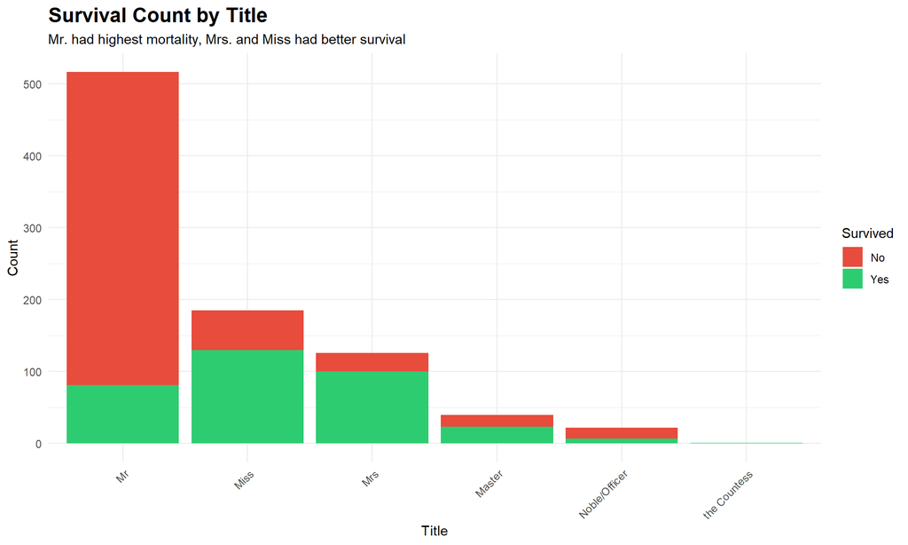

```r
title_survival <- train %>%
  group_by(Title, Survived) %>%
  summarise(Count = n(), .groups = "drop")

ggplot(title_survival, aes(x = reorder(Title, -Count), y = Count, fill = Survived)) +
  geom_bar(stat = "identity") +
  scale_fill_manual(values = c("No" = "#e74c3c", "Yes" = "#2ecc71")) +
  labs(title = "Survival Count by Title",
       subtitle = "Mr. had highest mortality, Mrs. and Miss had better survival",
       x = "Title",
       y = "Count",
       fill = "Survived") +
  theme_minimal() +
  theme(plot.title = element_text(size = 16, face = "bold"),
        axis.text.x = element_text(angle = 45, hjust = 1))
```

# 8 Predictive Modeling

## 8.1 Data Preparation for Modeling

```r
# Split data: 80% training, 20% validation
train_indices <- sample(1:nrow(train), size = 0.8 * nrow(train))
train_set <- train[train_indices, ]
validation_set <- train[-train_indices, ]

cat("Training set:", nrow(train_set), "passengers\n")
```

```
## Training set: 712 passengers
```

```r
cat("Validation set:", nrow(validation_set), "passengers\n")
```

```
## Validation set: 179 passengers
```

## 8.2 Baseline Model: Basic Features Only

```r
# Train logistic regression with basic features
baseline_model <- glm(Survived ~ Pclass + Sex + Age,
                      data = train_set,
                      family = binomial)

# Model summary
summary(baseline_model)
```

```
##
## Call:
## glm(formula = Survived ~ Pclass + Sex + Age, family = binomial,
##     data = train_set)
##
## Coefficients:
##                  Estimate Std. Error z value Pr(>|z|)
## (Intercept)      3.862970   0.441049   8.759  < 2e-16 ***
## Pclass2nd Class -1.235505   0.299444  -4.126 3.69e-05 ***
## Pclass3rd Class -2.387865   0.291544  -8.190 2.60e-16 ***
## Sexmale         -2.720023   0.209372 -12.991  < 2e-16 ***
## Age             -0.040281   0.008877  -4.537 5.69e-06 ***
## ---
## Signif. codes:  0 '***' 0.001 '**' 0.01 '*' 0.05 '.' 0.1 ' ' 1
##
## (Dispersion parameter for binomial family taken to be 1)
##
##     Null deviance: 951.69  on 711  degrees of freedom
## Residual deviance: 632.94  on 707  degrees of freedom
## AIC: 642.94
##
## Number of Fisher Scoring iterations: 5
```

```r
# Predictions
validation_set$pred_baseline_prob <- predict(baseline_model,
                                             validation_set,
                                             type = "response")
validation_set$pred_baseline <- factor(
  ifelse(validation_set$pred_baseline_prob > 0.5, "Yes", "No"),
  levels = c("No", "Yes")
)

# Confusion matrix
conf_matrix_baseline <- table(Predicted = validation_set$pred_baseline,
                              Actual = validation_set$Survived)
print(conf_matrix_baseline)
```

```
##          Actual
## Predicted No Yes
##       No  96  23
##       Yes 18  42
```

```r
# Accuracy
baseline_accuracy <- sum(diag(conf_matrix_baseline)) / sum(conf_matrix_baseline)
cat("\n✓ Baseline Model Accuracy:", round(baseline_accuracy * 100, 2), "%\n")
```

```
##
## ✓ Baseline Model Accuracy: 77.09 %
```

## 8.3 Improved Model: All Engineered Features

```r
# Train with all features
improved_model <- glm(Survived ~ Pclass + Sex + Age + Embarked +
                      FamilySize + Title + AgeGroup + FarePerPerson + HasCabin + IsAlone,
                      data = train_set,
                      family = binomial)

# Model summary
summary(improved_model)
```

```
##
## Call:
## glm(formula = Survived ~ Pclass + Sex + Age + Embarked + FamilySize +
##     Title + AgeGroup + FarePerPerson + HasCabin + IsAlone, family = binomial,
##     data = train_set)
##
## Coefficients:
##                      Estimate Std. Error z value Pr(>|z|)
## (Intercept)         1.841e+01  8.827e+02   0.021 0.983358
## Pclass2nd Class    -5.942e-01  5.212e-01  -1.140 0.254270
## Pclass3rd Class    -1.542e+00  5.278e-01  -2.922 0.003483 **
## Sexmale            -1.499e+01  8.827e+02  -0.017 0.986450
## Age                -4.670e-03  2.547e-02  -0.183 0.854524
## EmbarkedQ           7.892e-03  4.557e-01   0.017 0.986181
## EmbarkedS          -3.834e-01  2.994e-01  -1.280 0.200434
## FamilySize         -4.597e-01  1.218e-01  -3.775 0.000160 ***
## TitleMiss          -1.548e+01  8.827e+02  -0.018 0.986007
## TitleMr            -3.548e+00  6.506e-01  -5.453 4.94e-08 ***
## TitleMrs           -1.457e+01  8.827e+02  -0.017 0.986831
## TitleNoble/Officer -3.269e+00  9.100e-01  -3.592 0.000328 ***
## Titlethe Countess  -4.384e+00  1.248e+03  -0.004 0.997198
## AgeGroup.L         -1.372e+00  1.227e+00  -1.117 0.263788
## AgeGroup.Q         -4.746e-01  4.664e-01  -1.018 0.308897
## AgeGroup.C         -9.299e-02  3.811e-01  -0.244 0.807216
## AgeGroup^4          2.066e-01  2.673e-01   0.773 0.439591
## FarePerPerson       4.819e-03  4.645e-03   1.037 0.299538
## HasCabinYes         9.737e-01  4.274e-01   2.278 0.022708 *
## IsAloneYes         -2.578e-01  3.523e-01  -0.732 0.464338
## ---
## Signif. codes:  0 '***' 0.001 '**' 0.01 '*' 0.05 '.' 0.1 ' ' 1
##
## (Dispersion parameter for binomial family taken to be 1)
##
##     Null deviance: 951.69  on 711  degrees of freedom
## Residual deviance: 555.93  on 692  degrees of freedom
## AIC: 595.93
##
## Number of Fisher Scoring iterations: 13
```

```r
# Predictions
validation_set$pred_improved_prob <- predict(improved_model,
                                            validation_set,
                                            type = "response")
validation_set$pred_improved <- factor(
  ifelse(validation_set$pred_improved_prob > 0.5, "Yes", "No"),
  levels = c("No", "Yes")
)

# Confusion matrix
conf_matrix_improved <- table(Predicted = validation_set$pred_improved,
                             Actual = validation_set$Survived)
print(conf_matrix_improved)
```

```
##          Actual
## Predicted No Yes
##       No  96  19
##       Yes 18  46
```

```r
# Accuracy
improved_accuracy <- sum(diag(conf_matrix_improved)) / sum(conf_matrix_improved)
cat("\n✓ Improved Model Accuracy:", round(improved_accuracy * 100, 2), "%\n")
```

```
##
## ✓ Improved Model Accuracy: 79.33 %
```

## 8.4 Decision Tree Model

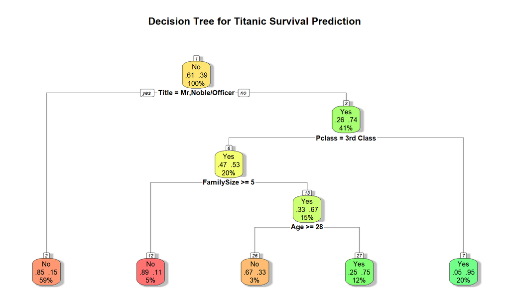

```r
# Train decision tree
tree_model <- rpart(Survived ~ Pclass + Sex + Age + FamilySize +
                    HasCabin + Embarked + Title,
                    data = train_set,
                    method = "class",
                    control = rpart.control(cp = 0.01))

# Visualize tree
rpart.plot(tree_model,
           main = "Decision Tree for Titanic Survival Prediction",
           extra = 104,
           box.palette = "RdYlGn",
           shadow.col = "gray",
           nn = TRUE,
           cex = 0.8)
```

```r
# Predictions
validation_set$pred_tree <- predict(tree_model, validation_set, type = "class")

# Confusion matrix
conf_matrix_tree <- table(Predicted = validation_set$pred_tree,
                         Actual = validation_set$Survived)
print(conf_matrix_tree)
```

```
##          Actual
## Predicted  No Yes
##       No  101  26
##       Yes  13  39
```

```r
# Accuracy
tree_accuracy <- sum(diag(conf_matrix_tree)) / sum(conf_matrix_tree)
cat("\n✓ Decision Tree Accuracy:", round(tree_accuracy * 100, 2), "%\n")
```

```
##
## ✓ Decision Tree Accuracy: 78.21 %
```

## 8.5 Model Comparison

```r
# Create comparison table
model_performance <- data.frame(
  Model = c("Baseline (Basic Features)",
            "Improved (All Features)",
            "Decision Tree"),
  Accuracy = c(
    round(baseline_accuracy * 100, 2),
    round(improved_accuracy * 100, 2),
    round(tree_accuracy * 100, 2)
  ),
  Features = c(
    "Pclass, Sex, Age",
    "All engineered features",
    "Selected features + rules"
  )
)

kable(model_performance, caption = "Model Performance Comparison") %>%
  kable_styling(bootstrap_options = c("striped", "hover"), full_width = FALSE)
```

Model Performance Comparison

| Model | Accuracy | Features |
| --- | --- | --- |
| Baseline (Basic Features) | 77.09 | Pclass, Sex, Age |
| Improved (All Features) | 79.33 | All engineered features |
| Decision Tree | 78.21 | Selected features + rules |

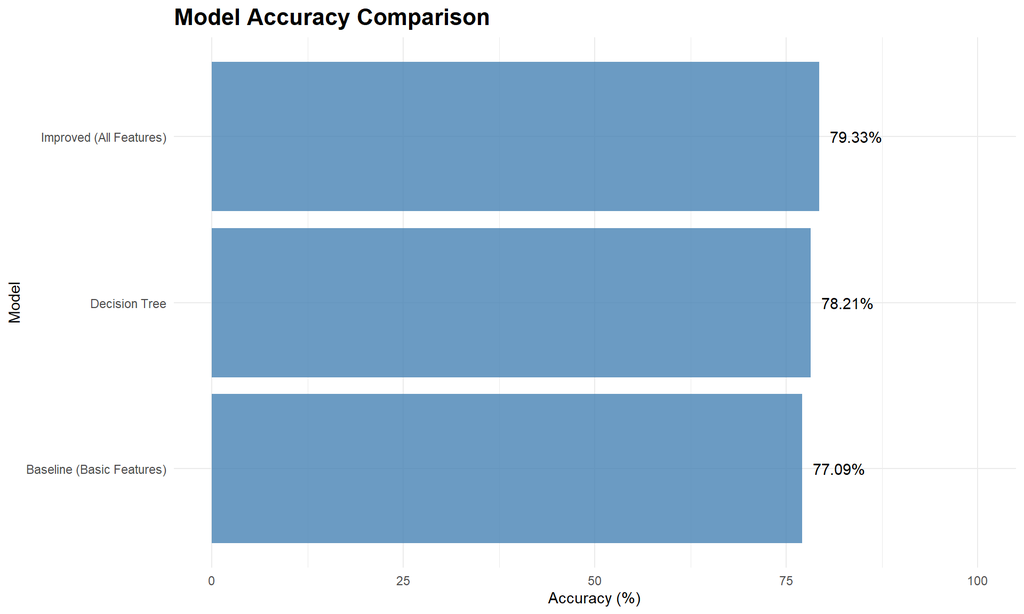

```r
# Visualize comparison
ggplot(model_performance, aes(x = reorder(Model, Accuracy), y = Accuracy)) +
  geom_bar(stat = "identity", fill = "steelblue", alpha = 0.8) +
  geom_text(aes(label = paste0(Accuracy, "%")), hjust = -0.2) +
  coord_flip() +
  ylim(0, 100) +
  labs(title = "Model Accuracy Comparison",
       x = "Model",
       y = "Accuracy (%)") +
  theme_minimal() +
  theme(plot.title = element_text(size = 16, face = "bold"))
```

## 8.6 Feature Importance Analysis

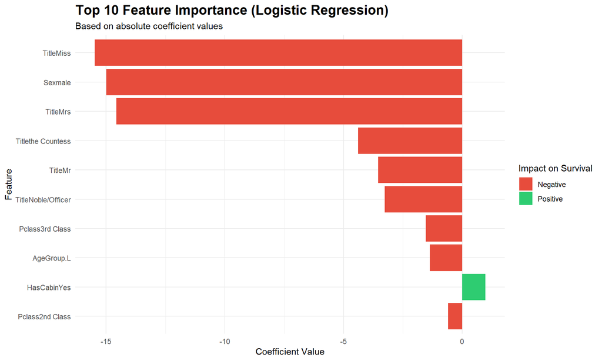

```r
# Extract coefficients from improved model
coef_df <- data.frame(
  Feature = names(coef(improved_model))[-1],
  Coefficient = coef(improved_model)[-1],
  AbsCoefficient = abs(coef(improved_model)[-1])
)

coef_df <- coef_df[order(-coef_df$AbsCoefficient), ]
coef_df <- head(coef_df, 10)

# Plot feature importance
ggplot(coef_df, aes(x = reorder(Feature, AbsCoefficient),
                    y = Coefficient,
                    fill = Coefficient > 0)) +
  geom_bar(stat = "identity") +
  coord_flip() +
  scale_fill_manual(values = c("TRUE" = "#2ecc71", "FALSE" = "#e74c3c"),
                   labels = c("Negative", "Positive")) +
  labs(title = "Top 10 Feature Importance (Logistic Regression)",
       subtitle = "Based on absolute coefficient values",
       x = "Feature",
       y = "Coefficient Value",
       fill = "Impact on Survival") +
  theme_minimal() +
  theme(plot.title = element_text(size = 16, face = "bold"))
```

# 9 Conclusions and Insights

## 9.1 Key Findings

**1. Gender Was the Strongest Predictor** - Women: 74% survival rate - Men: 19% survival rate - Evidence of “women and children first” protocol

**2. Socioeconomic Status Mattered** - 1st Class: 63% survived - 2nd Class: 47% survived  
- 3rd Class: 24% survived - Higher fares correlated with better survival chances

## 9.2 Model Performance

1. Sex (strongest)
2. Passenger class
3. Age
4. Family size
5. Title/social status

## 9.3 Practical Implications

These findings have modern applications for: - Emergency evacuation planning - Safety protocol design - Resource allocation during crises - Understanding human behavior in emergencies

## 9.4 Limitations

- 77% missing cabin data limits location-based analysis
- No crew behavior or lifeboat assignment data
- Predictions limited to historical context

### 9.4.1 Future Improvements:

1. **Ensemble Methods**: Combine multiple models (Random Forest, Gradient Boosting)
2. **Deep Learning**: Neural networks for complex pattern recognition
3. **External Data**: Incorporate historical records about lifeboat loading
4. **Survival Time Analysis**: Model when passengers likely perished (early vs late)

## 9.5 Final Thoughts

The Titanic tragedy remains a powerful case study in data science and social inequality. Our models successfully predict survival with high accuracy, but more importantly, they reveal the stark realities of early 20th-century social hierarchies and the critical importance of emergency preparedness.

> *“The significance of the Titanic lies not just in the tragedy itself, but in the lessons it teaches about human behavior, social structures, and the critical importance of safety protocols.”*

# 10 Technical Appendix

## 10.2 Data Dictionary (Final Dataset)

```r
final_vars <- data.frame(
  Variable = c("Survived", "Pclass", "Sex", "Age", "SibSp", "Parch",
               "Fare", "Embarked", "HasCabin", "FamilySize", "Title",
               "AgeGroup", "FarePerPerson", "IsAlone"),
  Type = c("Factor", "Factor", "Factor", "Numeric", "Integer", "Integer",
           "Numeric", "Factor", "Factor", "Integer", "Factor", "Ordered Factor",
           "Numeric", "Factor"),
  Description = c("Survival status", "Passenger class", "Gender",
                  "Age (imputed)", "Siblings/spouses aboard", "Parents/children aboard",
                  "Ticket fare", "Embarkation port", "Has cabin info",
                  "Total family members", "Title from name", "Age category",
                  "Fare divided by family size", "Traveling alone indicator")
)

kable(final_vars, caption = "Final Dataset Variables") %>%
  kable_styling(bootstrap_options = c("striped", "hover"), full_width = FALSE)
```

Final Dataset Variables

| Variable | Type | Description |
| --- | --- | --- |
| Survived | Factor | Survival status |
| Pclass | Factor | Passenger class |
| Sex | Factor | Gender |
| Age | Numeric | Age (imputed) |
| SibSp | Integer | Siblings/spouses aboard |
| Parch | Integer | Parents/children aboard |
| Fare | Numeric | Ticket fare |
| Embarked | Factor | Embarkation port |
| HasCabin | Factor | Has cabin info |
| FamilySize | Integer | Total family members |
| Title | Factor | Title from name |
| AgeGroup | Ordered Factor | Age category |
| FarePerPerson | Numeric | Fare divided by family size |
| IsAlone | Factor | Traveling alone indicator |